# 10 Data Visualizations for Data Flow Diagram and Graphs Assignment

```python
import pandas as pd
import numpy as np
import matplotlib.pyplot as plt

df = pd.read_csv('2022_Building_Energy_Benchmarking_20240920.csv')
display(df)
```

|  | OSEBuildingID | DataYear | BuildingName | BuildingType | TaxParcelIdentificationNumber | Address | City | State | ZipCode | Latitude | ... | ThirdLargestPropertyUseTypeGFA | Electricity(kWh) | SteamUse(kBtu) | NaturalGas(therms) | ComplianceStatus | ComplianceIssue | Electricity(kBtu) | NaturalGas(kBtu) | TotalGHGEmissions | GHGEmissionsIntensity |
| --- | --- | --- | --- | --- | --- | --- | --- | --- | --- | --- | --- | --- | --- | --- | --- | --- | --- | --- | --- | --- | --- |
| 0 | 1 | 2022 | MAYFLOWER PARK HOTEL | NonResidential | 0659000030 | 405 OLIVE WAY | SEATTLE | WA | 98101 | 47.61220 | ... | NaN | 1107295.0 | 2192383.0 | 13629.0 | Compliant | No Issue | 3778091.0 | 1362900.0 | 264.5 | 2.99 |
| 1 | 2 | 2022 | PARAMOUNT HOTEL | NonResidential | 0659000220 | 724 PINE ST | SEATTLE | WA | 98101 | 47.61307 | ... | NaN | 698673.0 | NaN | 27516.0 | Compliant | No Issue | 2383872.0 | 2751630.0 | 155.3 | 1.75 |
| 2 | 3 | 2022 | WESTIN HOTEL (Parent Building) | NonResidential | 0659000475 | 1900 5TH AVE | SEATTLE | WA | 98101 | 47.61367 | ... | 0.0 | 10599740.0 | 18793416.0 | 57000.0 | Compliant | No Issue | 36166313.0 | 5700000.0 | 1963.7 | 2.59 |
| 3 | 5 | 2022 | HOTEL MAX | NonResidential | 0659000640 | 620 STEWART ST | SEATTLE | WA | 98101 | 47.61412 | ... | NaN | 783804.0 | 1549427.0 | 15762.0 | Compliant | No Issue | 2674341.0 | 1576250.0 | 219.5 | 3.58 |
| 4 | 8 | 2022 | WARWICK SEATTLE HOTEL | NonResidential | 0659000970 | 401 LENORA ST | SEATTLE | WA | 98121 | 47.61375 | ... | 0.0 | 1374200.0 | NaN | 73621.0 | Compliant | No Issue | 4688770.0 | 7362130.0 | 409.0 | 3.60 |
| ... | ... | ... | ... | ... | ... | ... | ... | ... | ... | ... | ... | ... | ... | ... | ... | ... | ... | ... | ... | ... | ... |
| 3648 | 50877 | 2022 | BOEING Primary Standards Metrology (BLDG 15-30) | NonResidential | 7883608601 | 1420 S TRENTON ST | SEATTLE | WA | 98108 | 47.52429 | ... | NaN | NaN | NaN | NaN | Not Compliant | Portfolio Manager Not Connected to the City of... | NaN | NaN | NaN | NaN |
| 3649 | 50879 | 2022 | BUILDING CURE | NonResidential | 0660001525 | 1920 TERRY AVE | SEATTLE | WA | 98101 | 47.61689 | ... | NaN | 6982385.0 | NaN | 439548.0 | Compliant | No Issue | 23823898.0 | 43954750.0 | 2425.8 | 5.40 |
| 3650 | 50881 | 2022 | 400 University | NonResidential | 7137830000 | 400 UNIVERSITY ST | SEATTLE | WA | 98101 | 47.60844 | ... | 0.0 | 186214.0 | NaN | 0.0 | Compliant | No Issue | 635362.0 | 0.0 | 2.4 | 0.02 |
| 3651 | 50886 | 2022 | Broadstone VIN | Multifamily MR (5-9) | 1825049095 | 4106 STONE WAY N | SEATTLE | WA | 98103 | 47.65715 | ... | NaN | 247202.0 | NaN | NaN | Compliant | No Issue | 843455.0 | NaN | 3.2 | NaN |
| 3652 | 50893 | 2022 | CEDAR SPEEDSTER | NonResidential | 1972203575 | 401 N 36TH ST | SEATTLE | WA | 98103 | 47.65200 | ... | NaN | NaN | NaN | NaN | Not Compliant | Portfolio Manager Not Connected to the City of... | NaN | NaN | NaN | NaN |

3653 rows × 42 columns

## 3 Univariate Graphs

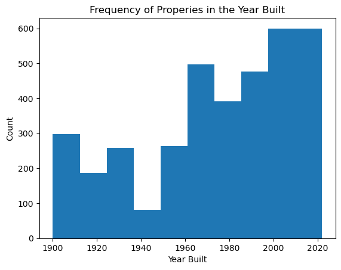

```python
plt.hist(df["YearBuilt"], bins = 10)
plt.xlabel("Year Built")
plt.ylabel("Count")
plt.title("Frequency of Properies in the Year Built")
plt.show()
```

The first graph is a histogram with the independent variable being the year the property was built and the response variable being the count of buildings from that year range. With a bin size set to 10, each bin holds years roughly in a 12 year range. Based on this plot, most of the properties were built in the last 60 years, around the 1960's. Strangely, there are very few properties built around the late 1930's to 1950's. Through pure speculation, this may be due to the World Wars at the time. Despite the higher volume of properties in the later half of the plot, there are still a considerable number of properties prior to th2 1950's. This means that when building our model, we will know that the distribution of data points in YearBuilt is somewhat balanced.

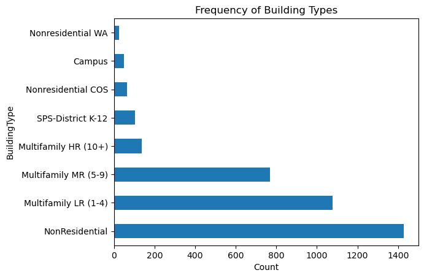

```python
df["BuildingType"].value_counts().plot(kind = "barh", xlabel="Count", title="Frequency of Building Types")
```

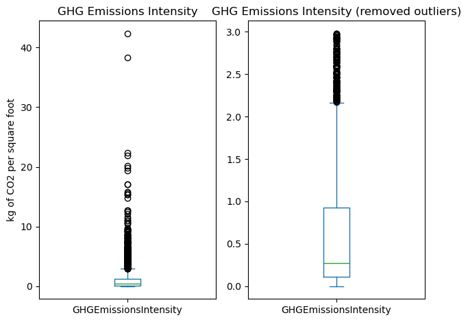

```python
# total GHG emissions divided by properties total gross floor area
# measured in kilograms of carbon dioxide equivalent per square foot.

Q1 = df["GHGEmissionsIntensity"].quantile(0.25)
Q3 = df["GHGEmissionsIntensity"].quantile(0.75)

outlier_boundary = Q3 + (1.5*(Q3-Q1))

fig, axes = plt.subplots(1, 2)

df["GHGEmissionsIntensity"].plot(kind='box', ax=axes[0], ylabel="kg of CO2 per square foot")
axes[0].set_title("GHG Emissions Intensity")

df.loc[df["GHGEmissionsIntensity"] <= outlier_boundary, "GHGEmissionsIntensity"].plot(kind='box', ax=axes[1])
axes[1].set_title("GHG Emissions Intensity (removed outliers)")

plt.tight_layout()
plt.show()
```

https://www.cnaught.com/blog/carbon-calculator-methodology#:~:text=Office%20space,individuals%20using%20the%20office%20space.

## 3 Bivariate Graphs

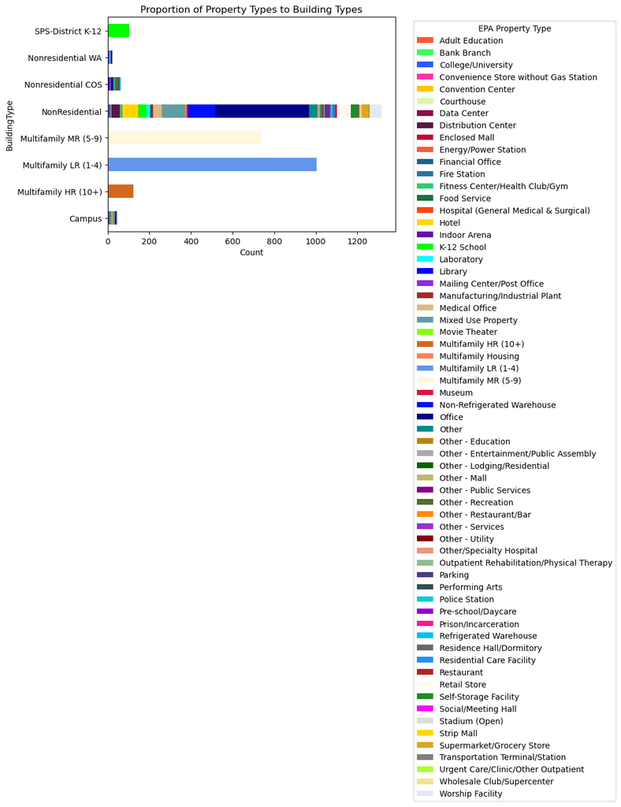

| EPAPropertyType | BuildingType | Adult Education | Bank Branch | College/University | Convenience Store without Gas Station | Convention Center | Courthouse | Data Center | Distribution Center | Enclosed Mall | ... | Retail Store | Self-Storage Facility | Social/Meeting Hall | Stadium (Open) | Strip Mall | Supermarket/Grocery Store | Transportation Terminal/Station | Urgent Care/Clinic/Other Outpatient | Wholesale Club/Supercenter | Worship Facility |
| --- | --- | --- | --- | --- | --- | --- | --- | --- | --- | --- | --- | --- | --- | --- | --- | --- | --- | --- | --- | --- | --- |
| 0 | Campus | 1 | 0 | 7 | 0 | 0 | 0 | 0 | 0 | 0 | ... | 1 | 0 | 0 | 0 | 0 | 0 | 2 | 0 | 0 | 0 |
| 1 | Multifamily HR (10+) | 0 | 0 | 0 | 0 | 0 | 0 | 0 | 0 | 0 | ... | 0 | 0 | 0 | 0 | 0 | 0 | 0 | 0 | 0 | 0 |
| 2 | Multifamily LR (1-4) | 0 | 0 | 0 | 0 | 0 | 0 | 0 | 0 | 0 | ... | 0 | 0 | 0 | 0 | 0 | 0 | 0 | 0 | 0 | 0 |
| 3 | Multifamily MR (5-9) | 0 | 0 | 0 | 0 | 0 | 0 | 0 | 0 | 0 | ... | 0 | 0 | 0 | 0 | 0 | 0 | 0 | 0 | 0 | 0 |
| 4 | NonResidential | 2 | 2 | 11 | 1 | 1 | 2 | 1 | 36 | 2 | ... | 66 | 37 | 7 | 1 | 9 | 35 | 1 | 2 | 2 | 55 |
| 5 | Nonresidential COS | 0 | 0 | 0 | 0 | 0 | 0 | 0 | 0 | 0 | ... | 0 | 0 | 1 | 0 | 0 | 0 | 1 | 0 | 0 | 0 |
| 6 | Nonresidential WA | 0 | 0 | 8 | 0 | 0 | 0 | 0 | 1 | 0 | ... | 0 | 0 | 0 | 1 | 0 | 0 | 0 | 0 | 0 | 0 |
| 7 | SPS-District K-12 | 0 | 0 | 0 | 0 | 0 | 0 | 0 | 0 | 0 | ... | 0 | 0 | 0 | 0 | 0 | 0 | 0 | 0 | 0 | 0 |

8 rows × 64 columns

```python
df_BuildingType = pd.crosstab(df["BuildingType"], df["EPAPropertyType"])
df_BuildingType.reset_index(inplace=True)

colors = ['#FF5733', '#33FF57', '#3357FF', '#FF33A1', '#FFC300',
          '#DAF7A6', '#900C3F', '#581845', '#C70039', '#FF5733',
          '#1F618D', '#2874A6', '#2ECC71', '#196F3D', '#FF4500',
          '#FFD700', '#6A0DAD', '#00FF00', '#00FFFF', '#0000FF',
          '#8A2BE2', '#A52A2A', '#DEB887', '#5F9EA0', '#7FFF00',
          '#D2691E', '#FF7F50', '#6495ED', '#FFF8DC', '#DC143C',
          '#000FFF', '#00008B', '#008B8B', '#B8860B', '#A9A9A9',
          '#006400', '#BDB76B', '#8B008B', '#556B2F', '#FF8C00',
          '#9932CC', '#8B0000', '#E9967A', '#8FBC8F', '#483D8B',
          '#2F4F4F', '#00CED1', '#9400D3', '#FF1493', '#00BFFF',
          '#696969', '#1E90FF', '#B22222', '#FFFAF0', '#228B22',
          '#FF00FF', '#DCDCDC', '#FFD700', '#DAA520', '#808080',
          '#ADFF2F', '#F0E68C', '#E6E6FA', '#FFF0F5', '#7CFC00',
          '#FFFACD']

ax = df_BuildingType.plot(x='BuildingType', kind='barh', stacked=True, color = colors, xlabel= "Count", title="Proportion of Property Types to Building Types")
plt.legend(bbox_to_anchor=(1.05, 1), loc='upper left', title="EPA Property Type")

plt.tight_layout()
plt.show()
display(df_BuildingType)
```

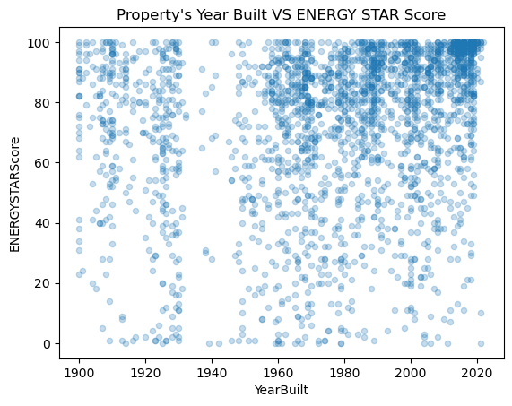

```python
df.plot(kind="scatter", alpha = 0.25, x = "YearBuilt", y = "ENERGYSTARScore", title = "Property's Year Built VS ENERGY STAR Score")
```

The second bivariate plot is a scatter plot with the year the property was built as the x-axis and the ENERGY STAR score as the y-axis. Here it can be seen that most of the data falls above an ENERGY STAR score of 70. Since the ENERGY STAR score is the percentile of the property's performance, most of the properties in Seattle perform better than 70% of all properties ENERGY STAR has queried from. Additionally, there appears to be less poor performing properties (score of less than 30) in the years of 1990-2022 compared to 1950-1980. This is evidence that our hypothesis that more recent buildings are more energy efficient seems to hold some truth.

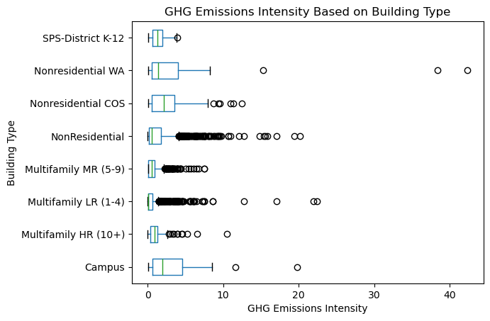

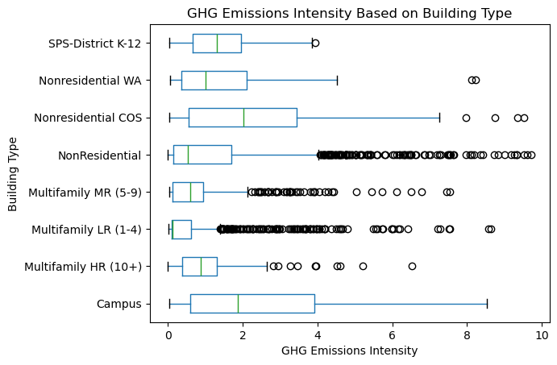

```python
_= df.loc[:, ["GHGEmissionsIntensity", "BuildingType"]].groupby("BuildingType").boxplot(subplots = False, vert = False, grid=False, xlabel= "GHG Emissions Intensity", ylabel = "Building Type")
_=plt.yticks(range(1,9), ['Campus','Multifamily HR (10+)', 'Multifamily LR (1-4)', 'Multifamily MR (5-9)', 'NonResidential', 'Nonresidential COS', 'Nonresidential WA','SPS-District K-12'])
_=plt.title("GHG Emissions Intensity Based on Building Type")
plt.show()


# removed some outliers for easier visualization
_= df.loc[df["GHGEmissionsIntensity"] < 10, ["GHGEmissionsIntensity", "BuildingType"]].groupby("BuildingType").boxplot(subplots = False, vert = False, grid=False, xlabel= "GHG Emissions Intensity", ylabel = "Building Type")
_=plt.yticks(range(1,9), ['Campus','Multifamily HR (10+)', 'Multifamily LR (1-4)', 'Multifamily MR (5-9)', 'NonResidential', 'Nonresidential COS', 'Nonresidential WA','SPS-District K-12'])
_=plt.title("GHG Emissions Intensity Based on Building Type")
plt.show()
```

The third bivariate plot is a boxplot of GHG emission intensity grouped by building type. In the first plot, there are no outliers removed. Because of this, it is clear that two Non-residential WA properties have extremely large GHG emission intensity. When removing some of the outliers (anything equal to or greater than 10), the second plot shows some more nuance. Nonresidential and Multifamily LR & MR both are heavily skewed towards the high end of emissions intensity, which makes sense as most of our data comes from these three categories. Also, it seems that nonresidential COS (City of Seattle) properties have the highest median intensity while Multifamily LR properties have the lowest.

## 2 High Dimensional Graphs

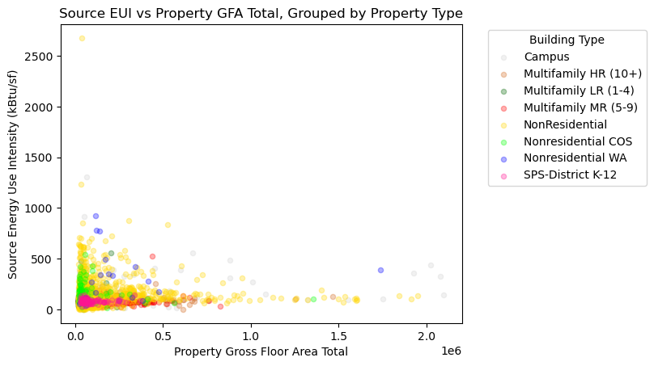

```python
colors = ['#d3d3d3', '#d2691e', '#006400', '#ff0000', '#ffd700', '#00ff00', '#0000ff', '#ff1493']
fig, ax = plt.subplots()

for i, (buildingType, group) in enumerate(df.groupby("BuildingType")):
    group.plot(kind="scatter", x="PropertyGFATotal", y="SourceEUI(kBtu/sf)", alpha=0.3, label=buildingType, color=colors[i % len(colors)], ax=ax)

plt.legend(title="Building Type")
plt.xlabel("Property Gross Floor Area Total")
plt.ylabel("Source Energy Use Intensity (kBtu/sf)")
plt.title("Source EUI vs Property GFA Total, Grouped by Property Type")
plt.legend(bbox_to_anchor=(1.05, 1), loc='upper left', title="Building Type")
plt.show()
```

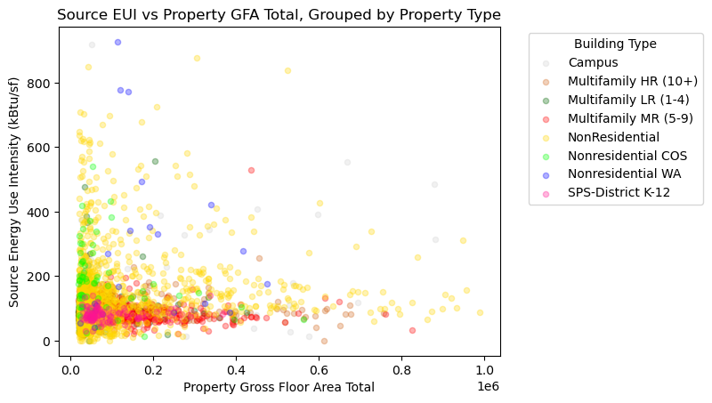

```python
# slicing dataframe to zoom in on the graph

new_df = df.loc[(df["SourceEUI(kBtu/sf)"] < 1000) & (df["PropertyGFATotal"] <1000000)]

colors = ['#d3d3d3', '#d2691e', '#006400', '#ff0000', '#ffd700', '#00ff00', '#0000ff', '#ff1493']
fig, ax = plt.subplots()

for i, (buildingType, group) in enumerate(new_df.groupby("BuildingType")):
    group.plot(kind="scatter", x="PropertyGFATotal", y="SourceEUI(kBtu/sf)", alpha=0.3, label=buildingType, color=colors[i % len(colors)], ax=ax)

plt.legend(title="Building Type")
plt.xlabel("Property Gross Floor Area Total")
plt.ylabel("Source Energy Use Intensity (kBtu/sf)")
plt.title("Source EUI vs Property GFA Total, Grouped by Property Type")
plt.legend(bbox_to_anchor=(1.05, 1), loc='upper left', title="Building Type")
plt.show()
```

The first high dimensional graph is a scatter plot between a property's total gross floor area and their source energy use intensity (annual energy used to operate divided by gross floor area) color-coded by the building type. Because there are many outliers that stretch the graph of its readability, the second plot has sliced down the dataset so as to "zoom in" on the majority of the data. At this level, it appears that for nonresidential properties, a higher total gross floor area does not increase source energy use intensity; the yellow points begin vertically spread in the lower ranges of area (although more heavily concentrated in lower intensity), but become more sparse and tend towards lower sourse energy use intensity. Overall, this graph suggests that larger gross floor areas will have a lower energy use intensity.

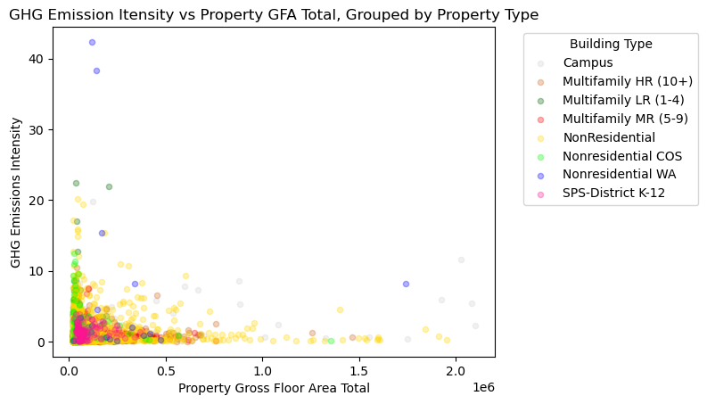

```python
colors = ['#d3d3d3', '#d2691e', '#006400', '#ff0000', '#ffd700', '#00ff00', '#0000ff', '#ff1493']
fig, ax = plt.subplots()

for i, (buildingType, group) in enumerate(df.groupby("BuildingType")):
    group.plot(kind="scatter", x="PropertyGFATotal", y="GHGEmissionsIntensity", alpha=0.3, label=buildingType, color=colors[i % len(colors)], ax=ax)

plt.legend(title="Building Type")
plt.xlabel("Property Gross Floor Area Total")
plt.ylabel("GHG Emissions Intensity")
plt.title("GHG Emission Itensity vs Property GFA Total, Grouped by Property Type")
plt.legend(bbox_to_anchor=(1.05, 1), loc='upper left', title="Building Type")
plt.show()
```

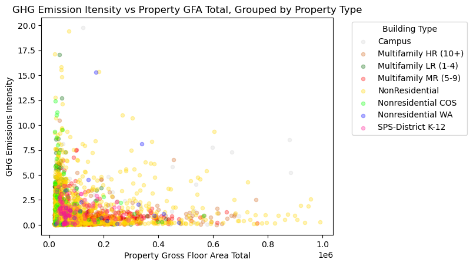

```python
# slicing dataframe to zoom in on the graph

new_df = df.loc[(df["GHGEmissionsIntensity"] < 20) & (df["PropertyGFATotal"] <1000000)]

colors = ['#d3d3d3', '#d2691e', '#006400', '#ff0000', '#ffd700', '#00ff00', '#0000ff', '#ff1493']
fig, ax = plt.subplots()

for i, (buildingType, group) in enumerate(new_df.groupby("BuildingType")):
    group.plot(kind="scatter", x="PropertyGFATotal", y="GHGEmissionsIntensity", alpha=0.3, label=buildingType, color=colors[i % len(colors)], ax=ax)

plt.legend(title="Building Type")
plt.xlabel("Property Gross Floor Area Total")
plt.ylabel("GHG Emissions Intensity")
plt.title("GHG Emission Itensity vs Property GFA Total, Grouped by Property Type")
plt.legend(bbox_to_anchor=(1.05, 1), loc='upper left', title="Building Type")
plt.show()
```

In the second high dimensional graph, the only variable changed is the y-axis which is now GHG emission intensity. Once again, due to outliers minmizing the clarity of the majority of the points, the data has been sliced to hone in on the main behavior. Much like the previous graph against energy use intensity, a higher gross floor area seems to have lower GHG emission intensity. These two high dimensional graphs might be evidence that larger properties consume more energy overall, they are porportionally more energy efficient and less polluting than smaller properties.

## 2 Additional Graphs Highlighting Problems

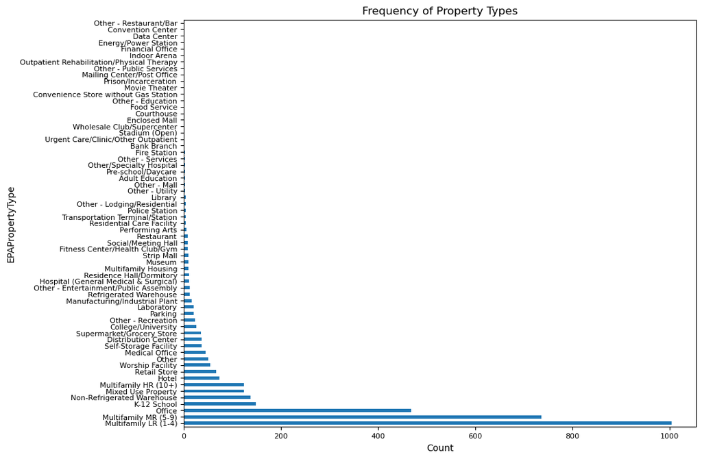

```python
df["EPAPropertyType"].value_counts().plot(kind = "barh", xlabel="Count", title="Frequency of Property Types", figsize=(10, 8), fontsize=8)
```

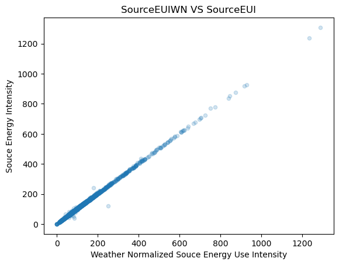

```python
#SourceEUI(kBtu/sf)
# Source Energy Use Intensity (EUI) is a property's Source Energy Use divided by its gross floor area.
# Source Energy Use is the annual energy used to operate the property, including losses from generation, transmission, & distribution.
# Source EUI is measured in thousands of British thermal units (kBtu) per square foot.

# SourceEUIWN(kBtu/sf)
#Weather Normalized (WN) Source Energy Use Intensity (EUI) is a property's WN Source Energy divided by its gross floor area.
#WN Source Energy is the Source Energy Use the property would have consumed during 30-year average weather conditions.
#WN Source EUI is measured in measured in thousands of British thermal units (kBtu) per square foot.

df.loc[df["SourceEUI(kBtu/sf)"] < 2000,].plot(kind = "scatter", x = "SourceEUIWN(kBtu/sf)",y = "SourceEUI(kBtu/sf)", alpha = 0.2, xlabel= "Weather Normalized Souce Energy Use Intensity", ylabel = "Souce Energy Intensity", title = "SourceEUIWN VS SourceEUI")
```

This scatter plot shows the relationship between SourceEUIWN(kBtu/sf), which is the source energy intensity of a property over a would-be 30 year average weather conditions, and source energy intensity. This relationship is so linear, that it is possible that these values are dupliates or so close to each other that we can neglect one of them to keep our dataset less redundant. It may also suggest that simply the annual source energy intensity is enough to average the next 30 years worth of energy use intensity given average weather conditions.

## 2 Descriptive Statistics Tables

```python
df["GHGEmissionsIntensity"].describe()
```

```
count    3444.000000
mean        1.128908
std         2.117535
min         0.000000
25%         0.110000
50%         0.430000
75%         1.260000
max        42.350000
Name: GHGEmissionsIntensity, dtype: float64
```

This summary table is for the GHG emission intensity. Unlike the boxplot used previously, this table give us exact numbers to pinpoint where the quantiles lie along with their max and min. The table has revealed that at least one data point has released 0 GHG emission, which is suspected to be an error that must be handled.

```python
df["ENERGYSTARScore"].describe()
```

```
count    2479.000000
mean       73.331585
std        25.691105
min         0.000000
25%        61.000000
50%        82.000000
75%        93.000000
max       100.000000
Name: ENERGYSTARScore, dtype: float64
```

This second summary table shows the spread of the ENERGY STAR scores of the properties. Previously hinted at before in the bivariate plots, half of Seattle's properties receive a score of at least 82 which places them in the 82 percentile of energy scorings. These high scorings show that Seattle's properties are uniquely energy efficient making our model less universal to apply to different cities.